# Project

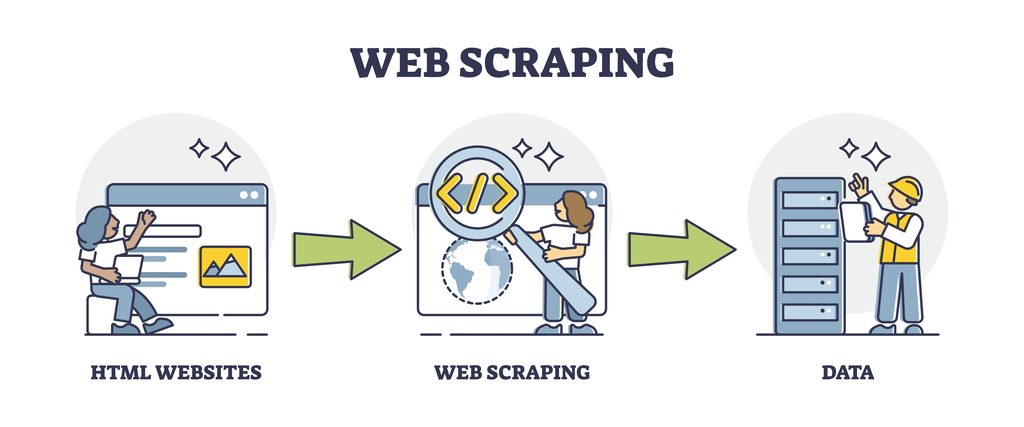

# FYP Project

During my first trimester at university, I collaborated with my group mates on an exciting Python project. This project focused on web scraping data from various websites, a skill that has become increasingly valuable in the realm of data science and analytics. It was a comprehensive and challenging endeavor that allowed us to apply our theoretical knowledge in a practical setting.

## The Project: Web Scraping with Python

Our project aimed to collect and analyze data from multiple online sources. Web scraping involves extracting data from websites and transforming it into a structured format for further analysis. This can be particularly useful for gathering large datasets that are not readily available through APIs or other conventional methods.

### Key Learning Outcomes

- **Understanding HTML and CSS**: We began by learning the basics of HTML and CSS to understand the structure of web pages. This foundational knowledge was crucial for identifying the elements we needed to scrape.
- **Using Python Libraries**: We utilized several powerful Python libraries, including:
  - **BeautifulSoup**: For parsing HTML and XML documents, making it easy to navigate the parse tree and extract the required data.
  - **Requests**: For making HTTP requests to fetch the web pages.
  - **Pandas**: For data manipulation and analysis once the data was scraped and structured.
- **Handling Dynamic Content**: Some websites use JavaScript to load content dynamically. We learned how to handle such cases using tools like Selenium, which automates web browsers and allows us to interact with JavaScript-heavy websites.
- **Data Cleaning and Processing**: After scraping the raw data, we focused on cleaning and processing it. This involved handling missing values, normalizing data formats, and filtering out irrelevant information to ensure our dataset was ready for analysis.
- **Ethical Considerations and Legal Compliance**: We also delved into the ethical and legal aspects of web scraping, ensuring that our practices were in line with the terms of service of the websites we scraped. Respecting robots.txt files and avoiding overloading servers with requests were key principles we adhered to.

### Achievements and Highlights

- **Team Collaboration**: Working with my group mates was a highly rewarding experience. We divided tasks based on our strengths and consistently communicated to ensure the project progressed smoothly. This collaboration not only strengthened our technical skills but also our teamwork and project management abilities.
- **Real-World Application**: The project provided us with a glimpse into real-world applications of web scraping. From gathering data for market analysis to monitoring trends on social media, the potential uses of our skills are vast and impactful.
- **Presentation and Documentation**: Upon completing the project, we documented our process and presented our findings to our peers and professors. This was an opportunity to showcase our work, receive valuable feedback, and highlight the practical implications of our project.

### Personal Reflection

This project stands out as one of the highlights of my academic journey so far. It was not only a testament to our technical abilities but also to our perseverance and creativity. I’m incredibly proud of what we achieved as a team, and this project has inspired me to further explore the field of data science and web technologies.